# sim250 sweep tables

## Table 1. Null GWAS simulation: LD fit

Excess Gaussian LD-fit loss (ridge 0.001) of each single panel over the mixed panel at the generating weight, per SNP; lower is better, and the mixed panel is 0 by definition. Chromosome 22, fixed 250 kb LD blocks. Each setting is a GWAS combining two ancestries' discovery samples at the stated composition; PRS-LDmix uses the matching weight. PRS-CS with automatic φ. Means over replicates with Monte Carlo standard errors in parentheses; within a replicate every method analyses the same simulated GWAS and scores the same target individuals. The seed rerun repeats first-ancestry PRS-CS with a different sampler seed and measures run-to-run variation.

| Pair | GWAS mix | Replicates | LD-fit loss above the generating weight First-ancestry panel | LD-fit loss above the generating weight Second-ancestry panel |
| --- | --- | --- | --- | --- |
| EUR + ASN | 90:10 | 20 | 0.309 (0.007) | 4.364 (0.071) |
|  | 70:30 | 20 | 1.250 (0.020) | 3.219 (0.055) |
|  | 50:50 | 20 | 2.299 (0.034) | 2.183 (0.039) |
| EUR + SAS | 90:10 | 20 | 0.153 (0.007) | 4.800 (0.099) |
|  | 70:30 | 20 | 0.612 (0.024) | 3.956 (0.077) |
|  | 50:50 | 20 | 1.110 (0.042) | 3.152 (0.061) |
| EUR + AFR | 90:10 | 20 | 1.714 (0.058) | 2.645 (0.068) |
|  | 70:30 | 20 | 5.996 (0.190) | 1.964 (0.054) |
|  | 50:50 | 20 | 10.453 (0.324) | 1.457 (0.041) |
| ASN + AFR | 90:10 | 20 | 1.424 (0.057) | 4.220 (0.059) |
|  | 70:30 | 20 | 4.944 (0.175) | 3.165 (0.049) |
|  | 50:50 | 20 | 8.617 (0.295) | 2.264 (0.039) |

## Table 2. Null GWAS simulation: score variance

Variance of target-sample scores in a GWAS with no true effects, relative to first-ancestry PRS-CS for the same GWAS, as a geometric-mean percentage change; negative values mean less spread in scores that carry no true signal. Chromosome 22, fixed 250 kb LD blocks. Each setting is a GWAS combining two ancestries' discovery samples at the stated composition; PRS-LDmix uses the matching weight. PRS-CS with automatic φ. Means over replicates with Monte Carlo standard errors in parentheses; within a replicate every method analyses the same simulated GWAS and scores the same target individuals. The seed rerun repeats first-ancestry PRS-CS with a different sampler seed and measures run-to-run variation.

| Pair | GWAS mix | Targets | Replicates | Null score variance vs. first-ancestry PRS-CS (%) Seed rerun | Null score variance vs. first-ancestry PRS-CS (%) PRS-LDmix | Null score variance vs. first-ancestry PRS-CS (%) Second-ancestry PRS-CS |
| --- | --- | --- | --- | --- | --- | --- |
| EUR + ASN | 90:10 | EUR | 20 | −1.7 (3.5) | −0.1 (2.9) | +9.2 (3.9) |
|  |  | ASN |  | −2.2 (3.5) | −0.6 (2.9) | +0.8 (3.3) |
|  | 70:30 | EUR | 20 | +2.7 (3.8) | −3.7 (2.6) | +8.5 (3.9) |
|  |  | ASN |  | +2.5 (4.0) | −6.5 (2.8) | −1.0 (3.6) |
|  | 50:50 | EUR | 20 | +3.3 (3.0) | −2.2 (2.9) | +2.1 (1.8) |
|  |  | ASN |  | +2.9 (3.1) | −6.6 (3.4) | −6.5 (1.9) |
| EUR + SAS | 90:10 | EUR | 20 | +3.2 (3.6) | +3.1 (2.2) | +11.3 (2.5) |
|  |  | SAS |  | −0.5 (4.3) | −0.4 (3.1) | +4.7 (3.6) |
|  | 70:30 | EUR | 20 | +1.8 (3.0) | −2.3 (3.4) | +7.0 (2.4) |
|  |  | SAS |  | −0.2 (3.2) | −4.7 (3.9) | +4.2 (3.2) |
|  | 50:50 | EUR | 20 | +2.7 (3.2) | +0.1 (3.1) | +7.1 (3.2) |
|  |  | SAS |  | +2.7 (4.0) | −3.3 (3.6) | +2.9 (4.4) |
| EUR + AFR | 90:10 | EUR | 20 | −0.7 (3.0) | −1.6 (2.9) | +28.2 (4.1) |
|  |  | AFR |  | 0.0 (3.4) | −3.3 (3.3) | +13.5 (3.7) |
|  | 70:30 | EUR | 20 | +2.2 (4.9) | +2.9 (3.5) | +15.7 (3.2) |
|  |  | AFR |  | +3.9 (5.6) | −4.2 (4.3) | −1.6 (4.4) |
|  | 50:50 | EUR | 20 | +4.2 (3.7) | +3.1 (3.0) | +9.8 (3.0) |
|  |  | AFR |  | +9.6 (4.3) | −3.5 (3.3) | −3.8 (3.7) |
| ASN + AFR | 90:10 | ASN | 20 | +3.7 (4.0) | −1.0 (2.8) | +31.0 (4.3) |
|  |  | AFR |  | +2.6 (6.5) | −5.0 (3.6) | +16.9 (5.0) |
|  | 70:30 | ASN | 20 | −2.5 (4.1) | +0.9 (3.4) | +15.1 (2.7) |
|  |  | AFR |  | −1.3 (4.9) | −2.5 (4.2) | +2.9 (3.2) |
|  | 50:50 | ASN | 20 | +3.5 (4.2) | −0.1 (3.6) | +10.5 (3.2) |
|  |  | AFR |  | +6.7 (5.3) | −10.0 (4.0) | −7.1 (3.8) |

## Table 3. Non-null GWAS simulation

Sparse causal effects shared across ancestries. Top-10% overlap is the share of target individuals in a method's top score decile who are also in first-ancestry PRS-CS's top decile; *r*<sup>2</sup> is the squared correlation between scores and true genetic values. Chromosome 22, fixed 250 kb LD blocks. Each setting is a GWAS combining two ancestries' discovery samples at the stated composition; PRS-LDmix uses the matching weight. PRS-CS with automatic φ. Means over replicates with Monte Carlo standard errors in parentheses; within a replicate every method analyses the same simulated GWAS and scores the same target individuals. The seed rerun repeats first-ancestry PRS-CS with a different sampler seed and measures run-to-run variation.

| Pair | GWAS mix | Targets | Replicates | Top-10% overlap with first-ancestry PRS-CS (%) Seed rerun | Top-10% overlap with first-ancestry PRS-CS (%) PRS-LDmix | Top-10% overlap with first-ancestry PRS-CS (%) Second-ancestry PRS-CS | *r*<sup>2</sup> with true genetic value First-ancestry PRS-CS | *r*<sup>2</sup> with true genetic value PRS-LDmix | *r*<sup>2</sup> with true genetic value Second-ancestry PRS-CS |
| --- | --- | --- | --- | --- | --- | --- | --- | --- | --- |
| EUR + ASN | 90:10 | EUR | 20 | 91.4 (0.3) | 91.4 (0.3) | 75.0 (1.3) | 0.569 (0.010) | 0.569 (0.011) | 0.486 (0.013) |
|  |  | ASN |  | 90.4 (0.3) | 90.2 (0.4) | 78.5 (0.8) | 0.551 (0.012) | 0.548 (0.013) | 0.478 (0.014) |
|  | 70:30 | EUR | 20 | 91.2 (0.4) | 90.5 (0.5) | 79.5 (1.3) | 0.590 (0.009) | 0.591 (0.010) | 0.545 (0.013) |
|  |  | ASN |  | 90.6 (0.5) | 89.7 (0.4) | 81.4 (0.8) | 0.590 (0.010) | 0.587 (0.011) | 0.552 (0.013) |
|  | 50:50 | EUR | 20 | 90.3 (0.4) | 88.4 (0.4) | 82.7 (1.0) | 0.589 (0.009) | 0.596 (0.010) | 0.582 (0.010) |
|  |  | ASN |  | 91.0 (0.4) | 87.9 (0.6) | 82.8 (0.9) | 0.596 (0.010) | 0.602 (0.011) | 0.592 (0.011) |
| EUR + SAS | 90:10 | EUR | 20 | 91.2 (0.3) | 91.1 (0.3) | 86.5 (0.5) | 0.549 (0.011) | 0.548 (0.011) | 0.527 (0.012) |
|  |  | SAS |  | 90.0 (1.4) | 88.8 (1.2) | 87.3 (1.5) | 0.520 (0.018) | 0.516 (0.017) | 0.497 (0.019) |
|  | 70:30 | EUR | 20 | 91.7 (0.3) | 91.0 (0.2) | 84.6 (0.4) | 0.427 (0.009) | 0.433 (0.009) | 0.429 (0.010) |
|  |  | SAS |  | 90.4 (1.5) | 89.2 (1.4) | 84.2 (1.6) | 0.376 (0.017) | 0.388 (0.018) | 0.381 (0.017) |
|  | 50:50 | EUR | 20 | 94.4 (0.1) | 87.8 (0.2) | 79.7 (0.3) | 0.230 (0.006) | 0.249 (0.006) | 0.254 (0.007) |
|  |  | SAS |  | 93.1 (1.0) | 84.2 (1.4) | 75.8 (1.6) | 0.178 (0.014) | 0.200 (0.014) | 0.206 (0.014) |
| EUR + AFR | 90:10 | EUR | 20 | 91.1 (0.3) | 91.5 (0.3) | 79.8 (0.6) | 0.542 (0.009) | 0.541 (0.009) | 0.485 (0.013) |
|  |  | AFR |  | 85.0 (1.6) | 83.3 (1.7) | 70.2 (2.3) | 0.394 (0.020) | 0.393 (0.019) | 0.352 (0.014) |
|  | 70:30 | EUR | 20 | 91.6 (0.3) | 88.7 (0.5) | 77.7 (1.1) | 0.425 (0.016) | 0.451 (0.012) | 0.442 (0.010) |
|  |  | AFR |  | 91.4 (1.5) | 85.7 (2.0) | 75.5 (2.6) | 0.207 (0.027) | 0.235 (0.026) | 0.252 (0.023) |
|  | 50:50 | EUR | 20 | 94.6 (0.2) | 77.9 (0.9) | 66.6 (1.1) | 0.216 (0.014) | 0.286 (0.012) | 0.305 (0.010) |
|  |  | AFR |  | 96.9 (0.9) | 80.5 (2.6) | 70.0 (2.9) | 0.090 (0.015) | 0.130 (0.019) | 0.154 (0.019) |
| ASN + AFR | 90:10 | ASN | 20 | 92.0 (0.4) | 91.5 (0.4) | 75.0 (1.0) | 0.571 (0.010) | 0.570 (0.010) | 0.473 (0.016) |
|  |  | AFR |  | 88.3 (1.7) | 88.3 (1.3) | 71.2 (2.2) | 0.372 (0.020) | 0.373 (0.021) | 0.337 (0.020) |
|  | 70:30 | ASN | 20 | 92.3 (0.4) | 87.9 (0.6) | 72.7 (1.0) | 0.443 (0.016) | 0.478 (0.013) | 0.454 (0.014) |
|  |  | AFR |  | 94.5 (1.4) | 89.5 (2.1) | 76.4 (3.3) | 0.179 (0.023) | 0.210 (0.023) | 0.232 (0.021) |
|  | 50:50 | ASN | 20 | 94.5 (0.3) | 76.4 (0.8) | 62.7 (0.9) | 0.230 (0.014) | 0.314 (0.013) | 0.342 (0.012) |
|  |  | AFR |  | 97.1 (0.8) | 84.0 (2.6) | 77.4 (3.7) | 0.105 (0.019) | 0.137 (0.019) | 0.160 (0.019) |

## Table 4. PRS-LDmix against the seed rerun and the single panels

Replicate-paired comparisons at the generating weight. Overlap and correlation are differences from the seed rerun (both first measured against first-ancestry PRS-CS); negative values mean PRS-LDmix changes scores more than a new sampler seed alone. Null score variance is PRS-LDmix relative to the seed rerun (geometric-mean percentage change). The last two columns are PRS-LDmix's *r*<sup>2</sup> minus single-panel PRS-CS's; positive values favour PRS-LDmix. pp, percentage points. Chromosome 22, fixed 250 kb LD blocks. Each setting is a GWAS combining two ancestries' discovery samples at the stated composition; PRS-LDmix uses the matching weight. PRS-CS with automatic φ. Means over replicates with Monte Carlo standard errors in parentheses; within a replicate every method analyses the same simulated GWAS and scores the same target individuals. The seed rerun repeats first-ancestry PRS-CS with a different sampler seed and measures run-to-run variation.

| Pair | GWAS mix | Targets | Replicates | PRS-LDmix vs. seed rerun Top-10% overlap (pp) | PRS-LDmix vs. seed rerun Correlation ×10<sup>3</sup> | PRS-LDmix vs. seed rerun Null score variance (%) | PRS-LDmix minus single-panel PRS-CS (*r*<sup>2</sup>) First ancestry | PRS-LDmix minus single-panel PRS-CS (*r*<sup>2</sup>) Second ancestry |
| --- | --- | --- | --- | --- | --- | --- | --- | --- |
| EUR + ASN | 90:10 | EUR | 20 | 0.00 (0.21) | −0.10 (0.15) | +1.6 (3.7) | −0.0006 (0.0018) | +0.0829 (0.0103) |
|  |  | ASN |  | −0.22 (0.33) | −0.12 (0.21) | +1.6 (3.9) | −0.0026 (0.0024) | +0.0705 (0.0048) |
|  | 70:30 | EUR | 20 | −0.70 (0.30) | −1.23 (0.26) | −6.3 (2.9) | +0.0017 (0.0024) | +0.0463 (0.0078) |
|  |  | ASN |  | −0.91 (0.55) | −2.06 (0.45) | −8.8 (2.8) | −0.0026 (0.0028) | +0.0352 (0.0048) |
|  | 50:50 | EUR | 20 | −1.92 (0.27) | −5.15 (0.52) | −5.3 (3.0) | +0.0065 (0.0029) | +0.0140 (0.0039) |
|  |  | ASN |  | −3.15 (0.74) | −8.03 (1.48) | −9.3 (2.9) | +0.0067 (0.0030) | +0.0106 (0.0027) |
| EUR + SAS | 90:10 | EUR | 20 | −0.17 (0.24) | −0.22 (0.18) | −0.1 (3.7) | −0.0008 (0.0011) | +0.0209 (0.0039) |
|  |  | SAS |  | −1.15 (1.51) | −0.89 (0.42) | +0.1 (4.7) | −0.0040 (0.0041) | +0.0191 (0.0062) |
|  | 70:30 | EUR | 20 | −0.73 (0.18) | −1.20 (0.14) | −4.0 (3.1) | +0.0057 (0.0013) | +0.0037 (0.0023) |
|  |  | SAS |  | −1.15 (1.40) | −2.71 (0.23) | −4.5 (2.9) | +0.0129 (0.0029) | +0.0072 (0.0040) |
|  | 50:50 | EUR | 20 | −6.56 (0.24) | −11.34 (0.31) | −2.5 (3.3) | +0.0191 (0.0013) | −0.0050 (0.0011) |
|  |  | SAS |  | −8.85 (1.70) | −18.35 (0.82) | −5.8 (3.8) | +0.0225 (0.0027) | −0.0059 (0.0025) |
| EUR + AFR | 90:10 | EUR | 20 | +0.40 (0.25) | −0.12 (0.16) | −0.9 (3.2) | −0.0003 (0.0017) | +0.0567 (0.0067) |
|  |  | AFR |  | −1.67 (1.26) | −1.31 (0.49) | −3.4 (4.2) | −0.0006 (0.0045) | +0.0411 (0.0112) |
|  | 70:30 | EUR | 20 | −2.91 (0.69) | −6.92 (1.73) | +0.8 (2.9) | +0.0262 (0.0052) | +0.0092 (0.0061) |
|  |  | AFR |  | −5.71 (1.68) | −6.61 (0.77) | −7.9 (2.6) | +0.0283 (0.0029) | −0.0167 (0.0070) |
|  | 50:50 | EUR | 20 | −16.69 (1.06) | −49.78 (4.68) | −1.0 (3.7) | +0.0694 (0.0042) | −0.0196 (0.0033) |
|  |  | AFR |  | −16.43 (2.25) | −27.69 (5.26) | −11.9 (4.2) | +0.0405 (0.0065) | −0.0239 (0.0023) |
| ASN + AFR | 90:10 | ASN | 20 | −0.48 (0.37) | −0.42 (0.14) | −4.6 (4.0) | −0.0015 (0.0014) | +0.0966 (0.0090) |
|  |  | AFR |  | 0.00 (1.29) | +0.06 (0.42) | −7.4 (4.8) | +0.0011 (0.0046) | +0.0362 (0.0081) |
|  | 70:30 | ASN | 20 | −4.43 (0.74) | −9.22 (1.35) | +3.5 (3.9) | +0.0352 (0.0046) | +0.0240 (0.0082) |
|  |  | AFR |  | −5.00 (1.94) | −5.64 (0.46) | −1.3 (4.1) | +0.0309 (0.0022) | −0.0227 (0.0057) |
|  | 50:50 | ASN | 20 | −18.09 (0.96) | −55.00 (3.20) | −3.4 (3.0) | +0.0837 (0.0030) | −0.0283 (0.0038) |
|  |  | AFR |  | −13.10 (2.21) | −18.97 (5.00) | −15.7 (3.5) | +0.0323 (0.0047) | −0.0228 (0.0015) |

## Figure. Per-replicate differences across the sweep

Each point is one replicate (simulated GWAS), with a violin for the distribution and a box for the median and quartiles; dashed line at zero. **a**, PRS-LDmix minus the seed rerun in top-10% overlap with first-ancestry PRS-CS (negative: PRS-LDmix changes the top decile more than a new sampler seed). **b**, PRS-LDmix minus first-ancestry PRS-CS in *r*<sup>2</sup> with the true genetic value (positive: PRS-LDmix more accurate). Replicates 1–20 of each setting.

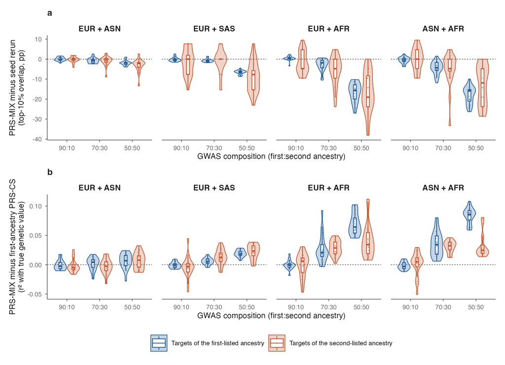